# jekyll-jupyter-notebook20261008-3183-yx235f

### extracting bigram statistics from real names

```python
# import the list of the most common US names (2018)
names = open('names.txt', 'r').read().splitlines()
print(f"total names = {len(names)}\n\
smallest name = {min((len(n)) for n in names)} characters\n\
longest name = {max((len(n)) for n in names)} characters")
names[:10]
```

```
total names = 32033
smallest name = 2 characters
longest name = 15 characters
```

```
['emma',
 'olivia',
 'ava',
 'isabella',
 'sophia',
 'charlotte',
 'mia',
 'amelia',
 'harper',
 'evelyn']
```

```python
# A bigram model predicts the next character
# iterate through the name Emma to extract all the bigram information
for n in names[:1]:
    chs = ['.'] + list(n) + ['.']
    for ch1, ch2 in zip(chs, chs[1:]):
        print(ch1, ch2)
```

```
. e
e m
m m
m a
a .
```

```python
# run the loop for all names, and keep track of the bigram counts
bigrams = {}
for n in names:
    chs = ['.'] + list(n) + ['.']
    for ch1, ch2 in zip(chs, chs[1:]):
        b = (ch1, ch2)
        bigrams[b] = bigrams.get(b, 0) + 1

# print the bigram - count dictionary, sorted on the 1-index item (count) in descending order (top 10 most abundant entries)
sorted(bigrams.items(), key = lambda key_value: -key_value[1])[:10]
```

```
[(('n', '.'), 6763),
 (('a', '.'), 6640),
 (('a', 'n'), 5438),
 (('.', 'a'), 4410),
 (('e', '.'), 3983),
 (('a', 'r'), 3264),
 (('e', 'l'), 3248),
 (('r', 'i'), 3033),
 (('n', 'a'), 2977),
 (('.', 'k'), 2963)]
```

```python
# using PyTorch to keep track of bigram counts
import torch

# initialize tensor to hold counts, 26 letters + '.' at start or end
bigram_frequencies = torch.zeros((27,27), dtype=torch.int32)

# helper dictionary to map each character to an integer
chars = sorted(list(set(''.join(names))))
ctoi = {c:i+1 for i,c in enumerate(chars)}
ctoi['.'] = 0

# inverse ctoi
itoc = {i:c for c,i in ctoi.items()}

ctoi
```

```
{'a': 1,
 'b': 2,
 'c': 3,
 'd': 4,
 'e': 5,
 'f': 6,
 'g': 7,
 'h': 8,
 'i': 9,
 'j': 10,
 'k': 11,
 'l': 12,
 'm': 13,
 'n': 14,
 'o': 15,
 'p': 16,
 'q': 17,
 'r': 18,
 's': 19,
 't': 20,
 'u': 21,
 'v': 22,
 'w': 23,
 'x': 24,
 'y': 25,
 'z': 26,
 '.': 0}
```

```
(np.float64(-0.5), np.float64(26.5), np.float64(26.5), np.float64(-0.5))
```

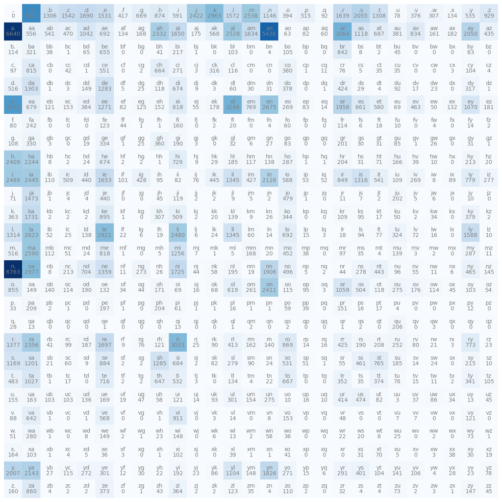

```python
# populating bigram count tensor
for n in names:
    chs = ['.'] + list(n) + ['.']
    for ch1, ch2 in zip(chs, chs[1:]):
        index_1 = ctoi[ch1]
        index_2 = ctoi[ch2]
        bigram_frequencies[index_1,index_2] += 1

#visualizing bigram tensor with matplotlib
import matplotlib.pyplot as plt
%matplotlib inline
plt.figure(figsize=(16,16))
plt.imshow(bigram_frequencies, cmap='Blues')
for i in range(27):
    for j in range(27):
        chstr = itoc[i] + itoc[j]
        plt.text(j, i, chstr, ha='center', va='bottom', color='gray')
        plt.text(j, i, bigrams[i,j].item(), ha='center', va='top', color='gray')
plt.axis('off')
```

#### the bigram frequency table can be used to calculate the second character in a bigram given the first

```python
# e.g., the probability distribution for starting letters
p = bigram_frequencies[0].float()
p = p / p.sum()
p
```

```
tensor([0.0000, 0.1377, 0.0408, 0.0481, 0.0528, 0.0478, 0.0130, 0.0209, 0.0273,
        0.0184, 0.0756, 0.0925, 0.0491, 0.0792, 0.0358, 0.0123, 0.0161, 0.0029,
        0.0512, 0.0642, 0.0408, 0.0024, 0.0117, 0.0096, 0.0042, 0.0167, 0.0290])
```

```python
# torch.multinomial() can be used to pull characters from the distribution
index = torch.multinomial(p, num_samples=1, replacement=True).item()
itoc[index]
```

```
'e'
```

```python
# repeating this process, starting from '.', and repeating until hitting another '.' to make... "names"
for _ in range(10):
    name = []
    index = 0
    while True:
        p = bigrams[index]
        p = p / p.sum()
        index = torch.multinomial(p, num_samples=1, replacement=True).item()
        name.append(itoc[index])
        if index==0:
            break
    print(''.join(name))
```

```
am.
ma.
jan.
kh.
veliyela.
dann.
sorkli.
na.
daininwin.
jak.
```

#### generating names with bigram frequency statistics is ...not the best

#### however, there is **some** information stored in the bigram statistics which lend a "nameness" to words generated with this model

#### to demonstrate the improvement, consider a bigram language model with a flat probability distribution

```python
# what happens when the name bigram probability statistics are removed (i.e., setting all probabilities to 1/27)
for _ in range(10):
    name = []
    index = 0
    while True:
        #p = bigrams[index]
        #p = p / p.sum()
        p = torch.ones(27)
        p = p / p.sum()
        index = torch.multinomial(p, num_samples=1, replacement=True).item()
        name.append(itoc[index])
        if index==0:
            break
    print(''.join(name))
```

```
vcnwwlbfqrgzeaojuabuer.
hjcvwh.
moivdstkintbxjhkeyshymxwzvbkboswvbicxbcjuggnwoiwtjxgrxfrkwmqblcwbfwcvgpy.
zqivg.
mmkcdilvve.
ajrvacvkk.
ylrtblhrlmtswogz.
wizvypntuhzancsgvnicskllfagp.
yugxdihshgeukpzymizsrphaouzlhl.
wysaoztwuchcdbkjqdnflbvjruwooie.
```

```python
# recalculating the probability distribution for each next character is wildly inefficient
# store the normalized rows in a new tensor P
# +1 is added to remove counts of 0 from tensor, model smoothing
P = (bigrams).float()

# care is necessary when doing the broadcast (division by row (dim=1) sums);
# default torch.tensor.sum(1) behavior is to squeeze out summed dimension;
# during broadcast, the nonextant dimension is imputed and causes column-wise division
print("trying P /= P.sum(1)")
P /= P.sum(1)
print(f"first row = {P[0]}")
print(f"row sum = {P[0].sum()}... incorrectly normalized, not 1!")

print("\ntrying P /= P.sum(1, keepdim=True)")
P = bigrams.float()
P /= P.sum(1, keepdim=True)
print(f"first row = {P[0]}")
print(f"row sum = {P[0].sum()}! now correctly normalized.")
```

```
trying P /= P.sum(1)
first row = tensor([0.0000, 0.1301, 0.4938, 0.4366, 0.3075, 0.0750, 0.4608, 0.3472, 0.1148,
        0.0334, 0.8352, 0.5879, 0.1126, 0.3821, 0.0625, 0.0497, 0.5019, 0.3382,
        0.1291, 0.2535, 0.2348, 0.0249, 0.1461, 0.3305, 0.1923, 0.0547, 0.3874])
row sum = 7.022482872009277... incorrectly normalized, not 1!

trying P /= P.sum(1, keepdim=True)
first row = tensor([0.0000, 0.1377, 0.0408, 0.0481, 0.0528, 0.0478, 0.0130, 0.0209, 0.0273,
        0.0184, 0.0756, 0.0925, 0.0491, 0.0792, 0.0358, 0.0123, 0.0161, 0.0029,
        0.0512, 0.0642, 0.0408, 0.0024, 0.0117, 0.0096, 0.0042, 0.0167, 0.0290])
row sum = 1.0! now correctly normalized.
```

### applying a notion of **loss** to the bigram model

##### finally, normalizing by $n$ gives the loss function: loss $=\huge \frac{-\log(L)}{n}$

```python
print("bigram  p       log(p)")

log_likelihood = 0.0
n = 0
for name in names:
    chs = ['.'] + list(name) + ['.']
    for ch1, ch2 in zip(chs, chs[1:]):
        index_1 = ctoi[ch1]
        index_2 = ctoi[ch2]
        probability = P[index_1, index_2]
        logprob = torch.log(probability)
        log_likelihood += logprob
        n += 1
        if n < 6:
            print(f"{ch1}{ch2:5}: {probability:5.4f} : {logprob:.4f}")
print(".\n.\n.")
print(f"loss = {-log_likelihood/n:4f}")
```

```
bigram  p       log(p)
.e    : 0.0478 : -3.0408
em    : 0.0377 : -3.2793
mm    : 0.0253 : -3.6772
ma    : 0.3899 : -0.9418
a.    : 0.1960 : -1.6299
.
.
.
loss = 2.454094
```

### making a neural network bigram language model

##### creating the training set with bigrams of the form $\large\{x,y\}$

##### the model must predict $\large y$ given $\large x$

```python
xs, ys = [], []

for name in names[:1]:
    chs = ['.'] + list(name) + ['.']
    for ch1, ch2 in zip(chs, chs[1:]):
        index_1 = ctoi[ch1]
        index_2 = ctoi[ch2]
        xs.append(index_1)
        ys.append(index_2)
        print(f"{ch1}{ch2}")
xs = torch.tensor(xs)
print(f"xs = {xs}")
ys = torch.tensor(ys)
print(f"ys = {ys}")
```

```
.e
em
mm
ma
a.
xs = tensor([ 0,  5, 13, 13,  1])
ys = tensor([ 5, 13, 13,  1,  0])
```

#### to encode the characters in a format compatible with a neural network, we use one-hot encoding

##### the neural network will take a $\large [1,27]$ tensor as input $\large X_{enc}$

```
tensor([[1., 0., 0., 0., 0., 0., 0., 0., 0., 0., 0., 0., 0., 0., 0., 0., 0., 0.,
         0., 0., 0., 0., 0., 0., 0., 0., 0.],
        [0., 0., 0., 0., 0., 1., 0., 0., 0., 0., 0., 0., 0., 0., 0., 0., 0., 0.,
         0., 0., 0., 0., 0., 0., 0., 0., 0.],
        [0., 0., 0., 0., 0., 0., 0., 0., 0., 0., 0., 0., 0., 1., 0., 0., 0., 0.,
         0., 0., 0., 0., 0., 0., 0., 0., 0.],
        [0., 0., 0., 0., 0., 0., 0., 0., 0., 0., 0., 0., 0., 1., 0., 0., 0., 0.,
         0., 0., 0., 0., 0., 0., 0., 0., 0.],
        [0., 1., 0., 0., 0., 0., 0., 0., 0., 0., 0., 0., 0., 0., 0., 0., 0., 0.,
         0., 0., 0., 0., 0., 0., 0., 0., 0.]])
```

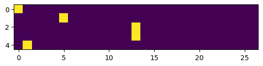

```python
import torch.nn.functional as F
xenc = F.one_hot(xs, num_classes=27).float()
print(xenc)
plt.imshow(xenc)
```

##### this nueral network will consist of a single layer of 27 neurons

##### the weight matrix $\large W$ holds the model weights

##### $\large X_{enc} \cdot W$ yields the activations for the model, equivalent to the $\log(counts)$ in the previous bigram probability model, known as the $logits$

##### $\large e^{logits}$ returns a tensor of values analagous to the counts, and is suitable for training

##### finally, normalizing $\huge \frac{e^{logits}}{\sum(e^{logits})}$ yields a probability distribution like before.

##### this function (which converts scalar values into probabilities) is known as **softmax**

```python
W = torch.randn((27,27), requires_grad=True)
logits = xenc @ W
counts = (xenc @ W).exp()
probabilities = counts / counts.sum(1, keepdim=True)
probabilities
```

```
tensor([[0.0779, 0.0157, 0.0149, 0.0381, 0.0079, 0.0146, 0.0100, 0.0091, 0.0114,
         0.0235, 0.0709, 0.0738, 0.0354, 0.0294, 0.0480, 0.1737, 0.0060, 0.0160,
         0.0190, 0.0493, 0.0295, 0.1431, 0.0032, 0.0113, 0.0453, 0.0061, 0.0171],
        [0.0213, 0.0275, 0.1373, 0.0106, 0.0412, 0.0144, 0.0265, 0.0473, 0.0905,
         0.0249, 0.0273, 0.0400, 0.0876, 0.0105, 0.0197, 0.0511, 0.0671, 0.0119,
         0.0266, 0.0398, 0.0202, 0.0515, 0.0162, 0.0310, 0.0339, 0.0045, 0.0195],
        [0.2060, 0.0541, 0.0111, 0.0817, 0.0237, 0.0124, 0.0090, 0.0287, 0.0407,
         0.0339, 0.0848, 0.0239, 0.0233, 0.0148, 0.0425, 0.0601, 0.0164, 0.0320,
         0.0253, 0.0249, 0.0177, 0.0233, 0.0036, 0.0202, 0.0438, 0.0141, 0.0279],
        [0.2060, 0.0541, 0.0111, 0.0817, 0.0237, 0.0124, 0.0090, 0.0287, 0.0407,
         0.0339, 0.0848, 0.0239, 0.0233, 0.0148, 0.0425, 0.0601, 0.0164, 0.0320,
         0.0253, 0.0249, 0.0177, 0.0233, 0.0036, 0.0202, 0.0438, 0.0141, 0.0279],
        [0.0093, 0.0359, 0.0159, 0.0182, 0.0388, 0.0268, 0.0116, 0.0479, 0.0711,
         0.0073, 0.0362, 0.0282, 0.0041, 0.0508, 0.3831, 0.0172, 0.0256, 0.0024,
         0.0170, 0.0213, 0.0064, 0.0400, 0.0100, 0.0075, 0.0365, 0.0101, 0.0210]],
       grad_fn=<DivBackward0>)
```

#### the neural network, then, is a function which takes the encoding of $\large x$ (the 27-dimensional one-hot vector), feeds it into a layer of 27 neurons, then through a softmax, to compute a probability distribution of all possible values of $\large y$

#### the loss of the untrained network can be computed just as before:

```python
nlls = torch.zeros(5)
for i in range(5):
    x = xs[i].item()
    y = ys[i].item()
    print("-----")
    print(f"bigram example {i+1}: {itoc[x]}{itoc[y]} indices {x}, {y})")
    print(f"model input (x): {x}")
    print(f"correct output (y): {y}")
    y_prob = probabilities[i,y]
    print(f"likelihood L({y}) according to model: {y_prob:.4f}")
    log_y_prob = -torch.log(y_prob)
    print(f"-log(L({y})) = {log_y_prob}")
    nlls[i] = log_y_prob
print("-----")
print(f"loss = average(sum(-log(L))) = {nlls.mean():.4f}")
```

```
-----
bigram example 1: .e indices 0, 5)
model input (x): 0
correct output (y): 5
likelihood L(5) according to model: 0.0146
-log(L(5)) = 4.226133346557617
-----
bigram example 2: em indices 5, 13)
model input (x): 5
correct output (y): 13
likelihood L(13) according to model: 0.0105
-log(L(13)) = 4.559112548828125
-----
bigram example 3: mm indices 13, 13)
model input (x): 13
correct output (y): 13
likelihood L(13) according to model: 0.0148
-log(L(13)) = 4.216307163238525
-----
bigram example 4: ma indices 13, 1)
model input (x): 13
correct output (y): 1
likelihood L(1) according to model: 0.0541
-log(L(1)) = 2.917027473449707
-----
bigram example 5: a. indices 1, 0)
model input (x): 1
correct output (y): 0
likelihood L(0) according to model: 0.0093
-log(L(0)) = 4.677889823913574
-----
loss = average(sum(-log(L))) = 4.1193
```

#### training the network

```python
W = torch.randn((27,27), requires_grad=True)
xs, ys = [], []

for name in names:
    chs = ['.'] + list(name) + ['.']
    for ch1, ch2 in zip(chs, chs[1:]):
        index_1 = ctoi[ch1]
        index_2 = ctoi[ch2]
        xs.append(index_1)
        ys.append(index_2)
xs = torch.tensor(xs)
ys = torch.tensor(ys)
num = xs.nelement()
print(f"number of training examples: {num}")
```

```
number of training examples: 228146
```

#### gradient descent: forward pass, backward pass, update parameters

```python
for k in range(201):
    # forward pass
    xenc = F.one_hot(xs, num_classes=27).float()
    logits = xenc @ W
    counts = logits.exp()
    p = counts / counts.sum(1, keepdim=True)
    loss = -p[torch.arange(num), ys].log().mean() # vectorized version of loss

    # backward pass
    W.grad = None # zero out gradients of W
    loss.backward()

    # update parameters
    W.data += -20 * W.grad

    if k%25 == 0:
        print(f"epoch {k} | loss = {loss.item():4f}")
```

```
epoch 0 | loss = 3.709481
epoch 25 | loss = 2.668840
epoch 50 | loss = 2.565713
epoch 75 | loss = 2.527498
epoch 100 | loss = 2.507567
epoch 125 | loss = 2.495595
epoch 150 | loss = 2.487746
epoch 175 | loss = 2.482254
epoch 200 | loss = 2.478205
```

```python
# generating names, but with the probability distribution of the softmaxed weights
for _ in range(10):
    name = []
    index = 0
    while True:
        xenc = F.one_hot(torch.tensor([index]), num_classes=27).float()
        logits = xenc @ W
        counts = logits.exp()
        p = counts / counts.sum(1, keepdim=True)

        index = torch.multinomial(p, num_samples=1, replacement=True).item()
        name.append(itoc[index])
        if index==0:
            break
    print(''.join(name))
```

```
ee.
s.
kos.
shine.
h.
kggked.
can.
jerrylmayrigorylenoryry.
ahayonde.
te.
```

#### the catch is that the neural network approach is much more flexible as a language model

#### namely, for an n-gram language model, $\large P$ will grow as $\large 27^{n}$, and quickly become computationally unmanageable

#### the quality limits of a bigram language model motivates the shift to a model that can accomodate more than 2 characters of 'context'